# Kepler Exoplanet Data Analysis

# Modeling using multiple ML algorithms

**What is the difference between koi_disposition and koi_pdisposition?**

koi_pdisposition and koi_disposition both describe the classification status of KOIs, but they differ in the stage of the classification process.

koi_pdisposition refers to the preliminary classification based on the initial automated vetting process, often reflecting early hypotheses about the KOI's status (e.g., "candidate" or "false positive").

On the other hand, koi_disposition represents the final, human-verified disposition after thorough analysis and additional validation.

While koi_pdisposition can guide early assessments, koi_disposition provides a more reliable and accurate categorization, making it the preferred choice for final evaluations and modeling efforts.

**Why are we choosing koi_disposition as the Target Class?**

The koi_disposition attribute represents the final classification of a Kepler Object of Interest (KOI) as either a confirmed exoplanet, a false positive, or a candidate pending further validation.

This attribute encapsulates the most conclusive outcome in the data, making it highly suitable for a classification task. By using koi_disposition as the target variable, we aim to leverage the most definitive labels to train a model that can predict the status of new or unclassified KOIs. Its categorical nature also ensures a clear objective for the classification model, enabling actionable insights into exoplanetary discoveries.

## RANDOM FOREST - CLASSIFICATION

## Handling the Categorial Data in Columns

Machine learning models like Random Forest require numerical inputs to function. Categorical data (e.g., strings like 'confirmed', 'false positive') needs to be converted into numerical form. This step ensures that the algorithm can interpret and learn patterns from all features.

In our dataset, we identified that some features contained categorical data, which machine learning algorithms cannot process directly. To address this, we implemented Label Encoding, a method that assigns a unique numeric value to each category. This ensured that all features were compatible with our Random Forest Classifier, enabling effective training and predictions.

```python
import pandas as pd
from sklearn.preprocessing import LabelEncoder
from sklearn.model_selection import train_test_split
from sklearn.ensemble import RandomForestClassifier
from sklearn.metrics import accuracy_score, classification_report, confusion_matrix
import seaborn as sns
import matplotlib.pyplot as plt
```

```python
from google.colab import files
uploaded = files.upload()
```

Upload widget is only available when the cell has been executed in the current browser session. Please rerun this cell to enable.

```
Saving cleaned_dataset.xlsx to cleaned_dataset.xlsx
```

```python
# Load the cleaned dataset

df = pd.read_excel(cleaned_data_path)

# Filter out 'CANDIDATE' rows from the target column
df = df[df['koi_disposition'] != 'CANDIDATE']

# Handle categorical features
categorical_columns = df.select_dtypes(include=['object']).columns

if not categorical_columns.empty:
    print(f"Categorical columns detected: {categorical_columns.tolist()}")

    # Use LabelEncoder for each categorical column
    label_encoders = {}
    for col in categorical_columns:
        le = LabelEncoder()
        df[col] = le.fit_transform(df[col])
        label_encoders[col] = le  # Save the encoders for future use (optional)
```

```
Categorical columns detected: ['kepoi_name', 'koi_disposition', 'koi_pdisposition', 'koi_tce_delivname']
```

We aim to classify the disposition of celestial objects (koi_disposition) using features derived from the Kepler dataset, such as stellar radii, orbital periods, and signal-to-noise ratios. This is a supervised classification task.

```
Accuracy: 0.9918032786885246

Classification Report:
               precision    recall  f1-score   support

           0       1.00      0.98      0.99       510
           1       0.99      1.00      0.99       954

    accuracy                           0.99      1464
   macro avg       0.99      0.99      0.99      1464
weighted avg       0.99      0.99      0.99      1464
```

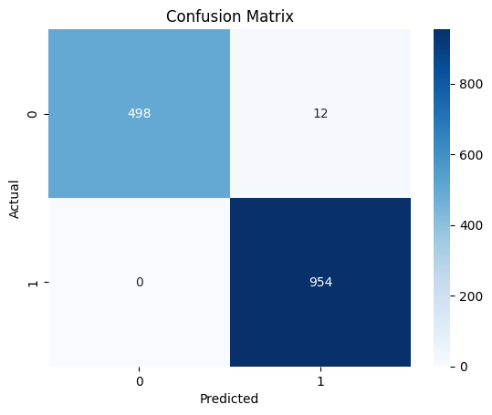

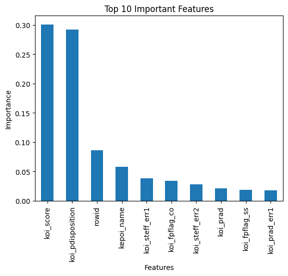

```python
# Define features (X) and target (y)
target_column = 'koi_disposition'
X = df.drop(columns=[target_column])
y = df[target_column]

# Split the data into training and testing sets
X_train, X_test, y_train, y_test = train_test_split(X, y, test_size=0.2, random_state=42)

# Train the Random Forest model
model = RandomForestClassifier(n_estimators=100, random_state=42)
model.fit(X_train, y_train)

# Make predictions
y_pred = model.predict(X_test)

# Evaluate the model
print("Accuracy:", accuracy_score(y_test, y_pred))
print("\nClassification Report:\n", classification_report(y_test, y_pred))

# Confusion Matrix
conf_matrix = confusion_matrix(y_test, y_pred)
sns.heatmap(conf_matrix, annot=True, fmt='d', cmap='Blues', xticklabels=model.classes_, yticklabels=model.classes_)
plt.title('Confusion Matrix')
plt.xlabel('Predicted')
plt.ylabel('Actual')
plt.show()

# Feature Importance
feature_importances = model.feature_importances_
important_features = pd.Series(feature_importances, index=X.columns).sort_values(ascending=False)

# Plot top 10 important features
important_features[:10].plot(kind='bar', title='Top 10 Important Features')
plt.xlabel('Features')
plt.ylabel('Importance')
plt.show()
```

To classify the disposition of celestial objects, we implemented a Random Forest Classifier. The model was trained using key features from the Kepler dataset, such as stellar radii, orbital periods, and depth of the transit event, after filtering the data to include only CONFIRMED and FALSE POSITIVE dispositions. The dataset was split into training and testing subsets in an 80-20 ratio.

The classifier achieved an accuracy of 99.18%, demonstrating excellent performance across both classes

## Support Vector Machines

```python
# Import required libraries
import pandas as pd
import numpy as np
import matplotlib.pyplot as plt
import seaborn as sns
from scipy import stats
from sklearn.preprocessing import StandardScaler
from sklearn.feature_selection import mutual_info_classif
from scipy.stats import chi2_contingency
import warnings
from scipy import stats
from sklearn.preprocessing import StandardScaler
from sklearn.decomposition import PCA
from sklearn.manifold import TSNE
from sklearn.cluster import KMeans
from sklearn.preprocessing import LabelEncoder
warnings.filterwarnings('ignore')
from sklearn.model_selection import train_test_split, GridSearchCV, KFold, StratifiedKFold, cross_val_score
from sklearn.svm import SVC
from sklearn.metrics import confusion_matrix, balanced_accuracy_score, classification_report, cohen_kappa_score, f1_score
from yellowbrick.classifier import ClassificationReport, ClassPredictionError, ConfusionMatrix
from yellowbrick.target import FeatureCorrelation
from yellowbrick.features import rank2d, RadViz, Rank2D
from yellowbrick.classifier import DiscriminationThreshold, PrecisionRecallCurve, ROCAUC
from yellowbrick.model_selection import feature_importances, CVScores, RFECV, FeatureImportances
from yellowbrick.model_selection import LearningCurve, ValidationCurve
from yellowbrick.classifier import ClassificationReport, ClassPredictionError, ConfusionMatrix

# Set plotting style
# plt.style.use('seaborn')
sns.set_palette('husl')
```

```python
cleaned_data_path = '/content/cleaned_dataset.xlsx'

data = pd.read_excel(cleaned_data_path)
```

#### Selecting Columns for Prediction

We eliminate all the columns that are either of the following:

- Assigned after other values are measured from readings
- Contain ID or name attributes

```python
ALL_COLUMNS = data.columns
ERROR_COLUMNS = [col for col in ALL_COLUMNS if "err" in col]
EXCLUDE = ["rowid", "kepid", "kepoi_name", "koi_score", "koi_disposition", "koi_pdisposition", "koi_tce_delivname", "koi_tce_plnt_num"]
TO_USE = list(set(ALL_COLUMNS) - set(EXCLUDE))
```

```python
print(f"Columns being analysed: {len(TO_USE)}")
data[TO_USE].head()
```

```
Columns being analysed: 39
```

|  | koi_fpflag_ec | koi_duration | koi_insol_err2 | koi_impact_err2 | koi_teq | koi_fpflag_co | koi_depth | koi_steff_err1 | koi_insol | koi_period | ... | koi_period_err1 | koi_impact_err1 | koi_duration_err2 | koi_srad_err2 | koi_prad_err1 | dec | ra | koi_depth_err2 | koi_time0bk_err2 | koi_slogg |
| --- | --- | --- | --- | --- | --- | --- | --- | --- | --- | --- | --- | --- | --- | --- | --- | --- | --- | --- | --- | --- | --- |
| 0 | 0 | 2.95750 | -16.65 | -0.146 | 793 | 0 | 615.8 | 81 | 93.59 | 9.488036 | ... | 2.775000e-05 | 0.318 | -0.08190 | -0.061 | 0.26 | 48.141651 | 291.93423 | -19.5 | -0.002160 | 4.467 |
| 1 | 0 | 4.50700 | -1.62 | -0.443 | 443 | 0 | 874.8 | 81 | 9.11 | 54.418383 | ... | 2.479000e-04 | 0.059 | -0.11600 | -0.061 | 0.32 | 48.141651 | 291.93423 | -35.5 | -0.003520 | 4.467 |
| 2 | 0 | 1.78220 | -10.49 | -0.077 | 638 | 0 | 10829.0 | 158 | 39.30 | 19.899140 | ... | 1.494000e-05 | 5.126 | -0.03410 | -0.078 | 3.92 | 48.134129 | 297.00482 | -171.0 | -0.000581 | 4.544 |
| 3 | 0 | 2.40641 | -230.35 | -0.092 | 1395 | 0 | 8079.2 | 157 | 891.96 | 1.736952 | ... | 2.630000e-07 | 0.115 | -0.00537 | -0.067 | 8.50 | 48.285210 | 285.53461 | -12.8 | -0.000115 | 4.564 |
| 4 | 0 | 1.65450 | -314.24 | -0.478 | 1406 | 0 | 603.3 | 169 | 926.16 | 2.525592 | ... | 3.761000e-06 | 0.235 | -0.04200 | -0.133 | 0.88 | 48.226200 | 288.75488 | -16.9 | -0.001130 | 4.438 |

5 rows × 39 columns

We extract only those rows which are either positive or negative examples i.e. the disposition value is not CANDIDATE. This is because CANDIDATE is the default value for all obects of interest picked up by Kepler. The labels CONFIRMED and FALSE POSITIVE serve as our positive and negative labels

Difference between disposition and pdisposition? We can use either of the two columns as our target variable, since both of them contain the target labels we desire. While pdisposition gives us the most probable labels based on the physical explanation given by the readings, disposition values are based on the NASA Exoplanet Archive Data.

```python
np.unique(data["koi_disposition"].values)
```

```
array(['CANDIDATE', 'CONFIRMED', 'FALSE POSITIVE'], dtype=object)
```

```python
subset_df = data[data["koi_disposition"] != "CANDIDATE"]
print(subset_df.shape)
subset_df.head()
```

```
(7316, 47)
```

|  | rowid | kepid | kepoi_name | koi_disposition | koi_pdisposition | koi_score | koi_fpflag_nt | koi_fpflag_ss | koi_fpflag_co | koi_fpflag_ec | ... | koi_steff_err2 | koi_slogg | koi_slogg_err1 | koi_slogg_err2 | koi_srad | koi_srad_err1 | koi_srad_err2 | ra | dec | koi_kepmag |
| --- | --- | --- | --- | --- | --- | --- | --- | --- | --- | --- | --- | --- | --- | --- | --- | --- | --- | --- | --- | --- | --- |
| 0 | 1 | 10797460 | K00752.01 | CONFIRMED | CANDIDATE | 1.000 | 0 | 0 | 0 | 0 | ... | -81 | 4.467 | 0.064 | -0.096 | 0.927 | 0.105 | -0.061 | 291.93423 | 48.141651 | 15.347 |
| 1 | 2 | 10797460 | K00752.02 | CONFIRMED | CANDIDATE | 0.969 | 0 | 0 | 0 | 0 | ... | -81 | 4.467 | 0.064 | -0.096 | 0.927 | 0.105 | -0.061 | 291.93423 | 48.141651 | 15.347 |
| 2 | 3 | 10811496 | K00753.01 | FALSE POSITIVE | FALSE POSITIVE | 0.000 | 0 | 1 | 0 | 0 | ... | -176 | 4.544 | 0.044 | -0.176 | 0.868 | 0.233 | -0.078 | 297.00482 | 48.134129 | 15.436 |
| 3 | 4 | 10848459 | K00754.01 | FALSE POSITIVE | FALSE POSITIVE | 0.000 | 0 | 1 | 0 | 0 | ... | -174 | 4.564 | 0.053 | -0.168 | 0.791 | 0.201 | -0.067 | 285.53461 | 48.285210 | 15.597 |
| 4 | 5 | 10854555 | K00755.01 | CONFIRMED | CANDIDATE | 1.000 | 0 | 0 | 0 | 0 | ... | -211 | 4.438 | 0.070 | -0.210 | 1.046 | 0.334 | -0.133 | 288.75488 | 48.226200 | 15.509 |

5 rows × 47 columns

#### Obtaining X and y

We can encode the categorical labels to 1 and 0 for easier comparison

CONFIRMED - 1 FALSE POSITIVE - 0

```python
X = subset_df[TO_USE].values
y = subset_df["koi_disposition"].apply(lambda x: x=='CONFIRMED').astype(int).values
subset_df["koi_disposition"].value_counts()
```

| koi_disposition | count |
| --- | --- |
| FALSE POSITIVE | 5023 |
| CONFIRMED | 2293 |

**dtype:** int64

#### Splitting into Train and Test sets

- Scale the values to make the models less computationally expensive and convert all the values to the same range
- Split into train and test sets

```python
X = StandardScaler().fit_transform(X)
X = PCA(n_components=30).fit_transform(X)
X_train, X_test, y_train, y_test = train_test_split(X, y, test_size=0.33, random_state=0, stratify=y)
X_train.shape, X_test.shape, y_train.shape, y_test.shape
```

```
((4901, 30), (2415, 30), (4901,), (2415,))
```

Since the dataset is imbalanced, we cannot use accuracy, hence we opt for the following metrics -

- Confusion Matrix
- F1 Score
- Cohen Kappa Score
- Balanced Accuracy Score

```python
def performance(test, pred):
    conf_matrix = confusion_matrix(test, pred)
    f1 = f1_score(test, pred)
    report = classification_report(test, pred)
    accuracy = balanced_accuracy_score(test, pred)
    kappa = cohen_kappa_score(test, pred)
    print(f"F1 Score: {f1}")
    print(f"Kappa Score: {kappa}")
    print(f"Accuracy Score: {accuracy}")
    print(f"Confusion Matrix:\n{conf_matrix}")
    print(report)
```

#### Cross Validation

```python
def crossValidationCheck(classifier, X, y, K=10):

    cv = KFold(n_splits=K, random_state=1, shuffle=True)
    scores = cross_val_score(classifier, X, y, scoring='f1', cv=cv, n_jobs=-1)
    print(f"Average F1 score over {K}-Folds: {scores.mean()}")

    visualizer = CVScores(classifier, cv=cv, scoring='f1')
    visualizer.fit(X, y)
    #visualizer.show(f"{classifier[:5]}_cv_error.png", dpi=600)

    visualizer = LearningCurve(classifier, cv=cv, scoring='f1', n_jobs=-1)
    visualizer.fit(X, y)
    #visualizer.show(f"{classifier[:5]}_learn_curve_error.png", dpi=600)

    cv = StratifiedKFold(n_splits=K, random_state=1, shuffle=True)
    scores = cross_val_score(classifier, X, y, scoring='f1', cv=cv, n_jobs=-1)
    print(f"Average F1 score over Stratified {K}-Folds: {scores.mean()}")

    visualizer = CVScores(classifier, cv=cv, scoring='f1')
    visualizer.fit(X, y)
    #visualizer.show(f"{classifier[:5]}_cv_strat_error.png", dpi=600)

    visualizer = LearningCurve(classifier, cv=cv, scoring='f1', n_jobs=-1)
    visualizer.fit(X, y)
    #visualizer.show(f"{classifier[:5]}_learn_curve_strat_error.png", dpi=600)
```

#### Feature Importance

```python
def getFeatureImportance(model, X, y):
    viz = FeatureImportances(model, labels=TO_USE)
    viz.fit(X, y)
    #viz.show(f"{model}_imp_error.png", dpi=600)
```

Training and prediction using SVM

```python
classifier = SVC(kernel='rbf', random_state=0)
classifier.fit(X_train, y_train)
pred = classifier.predict(X_test)
```

```python
performance(y_test, pred)
```

```
F1 Score: 0.9690992767915845
Kappa Score: 0.9548960289987876
Accuracy Score: 0.9786476202010029
Confusion Matrix:
[[1631   27]
 [  20  737]]
              precision    recall  f1-score   support

           0       0.99      0.98      0.99      1658
           1       0.96      0.97      0.97       757

    accuracy                           0.98      2415
   macro avg       0.98      0.98      0.98      2415
weighted avg       0.98      0.98      0.98      2415
```

```python
def getClassificationReport(classifier):
    visualizer = ClassificationReport(classifier, classes=[0, 1])
    visualizer.fit(X_train, y_train)
    visualizer.score(X_test, y_test)
    #visualizer.show(f"{classifier}_report_error.png", dpi=600)
```

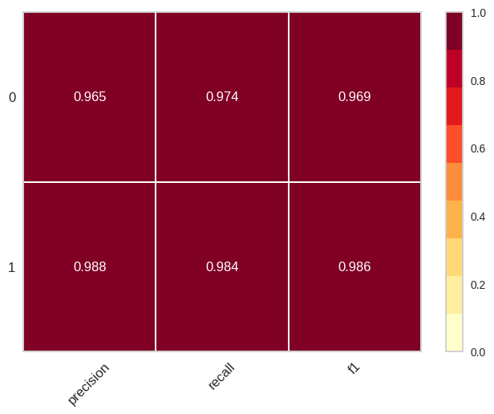

```python
getClassificationReport(classifier)
```

```
Average F1 score over 10-Folds: 0.9693565504745087
Average F1 score over Stratified 10-Folds: 0.9689157724271853
```

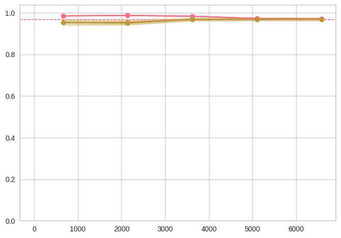

```python
crossValidationCheck(classifier, X, y, K=10)
```